# WED 03/14/2018 Assignment

Updated 2018-03-13

#### THE PROBLEM

The TESTDATA dataset contains eight variables. Two of the variables are samples from a Normal or approximately Normal distribution. One is a sample from a Uniform distribution. One is a sample from an Exponential distribution with a constant subtracted from each value. The other four are distributions we have not worked with. Complete the descriptive analysis described below to help you identify which distribution is which. Go to DISTRIBUTION IDENTIFICATION on AsULearn to input your identification for each of the eight distributions.

#### VARIABLE SUMMARIES

Summarize the mean, standard deviation, skewness, and kurtosis for all variables in the TESTDATA dataset using `dplyr` piping and functions. The output should be a single tibble containing all the summary statistics. The `summarize_all()` and `fun()` functions ([see example](http://dplyr.tidyverse.org/reference/summarise_all.html)) will be helpful in completing this portion.

The qqPlot function is similar to using `qqnorm` with `qqline`, but it also includes guidelines to assist in determining whether the points are close enough to the straight line representing theoretically normal data.

##### Variable 1

```r
TESTDATA %>% summarize(mean=mean(V1), sd=sd(V1), skew=skewness(V1), kurt=kurtosis(V1))
```

```
##        mean      sd      skew     kurt
## 1 0.1481949 1.85166 0.9650352 8.516016
```

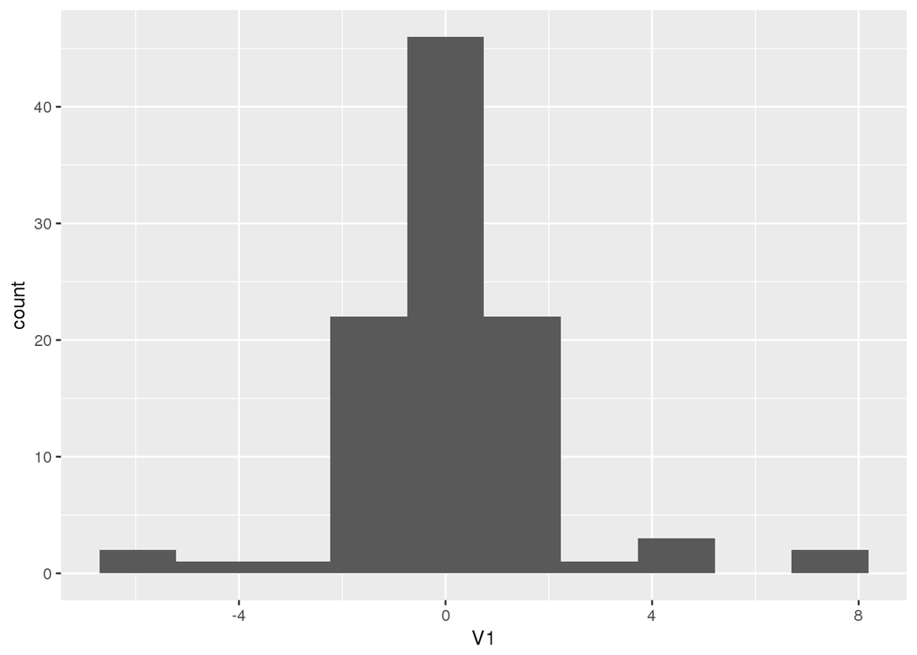

```r
ggplot(TESTDATA, aes(x=V1)) + geom_histogram(bins=10)
```

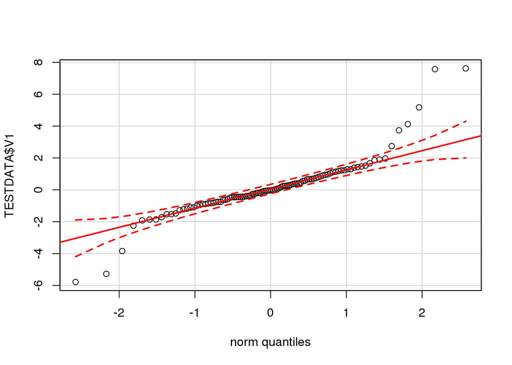

```r
qqPlot(TESTDATA$V1)
```